# Part II - Prosper Loan data Exploration Project

## by Kevin Austine Otieno

## Investigation Overview

For this project I chose to work more with numerical data as they give clear insights than variable that make you do more of imaginations. I looked into factors affecting perfomance of loans with a director major on defaulted and completed loans and also some like interet rates the borrowers with already mortage will go for, or with listing category, what amount do they go for and als the high income eraners what kind of interet rates entice the.

## Dataset Overview

> This data set contains 113,937 loans with 81 variables on each loan, including loan amount, borrower rate (or interest rate), current loan status, borrower income, and many others. For this project I only chose to work with 19 variable that I felt were directly aligned with the question i was looking to find answers for. Among them as below
> - **Term**, - The length of the loan expressed in months.
> - **LoanStatus** - The current status of the loan: Cancelled, Chargedoff, Completed, Current, Defaulted, FinalPaymentInProgress, PastDue.
> - **BorrowerRate** - The Borrower's interest rate for this loan.
> - **IncomeRange** - The income range of the borrower at the time the listing was created.
> - **IsBorrowerHomeowne**r -A Borrower will be classified as a homowner if they have a mortgage on their credit profile or provide documentation confirming they are a homeowner.
> - **ProsperRating (Alpha)** - The Prosper Rating assigned at the time the listing was created between AA - HR. Applicable for loans originated after July 2009.
> - **ListingCategory (numeric)** - The category of the listing that the borrower selected when posting their listing: 0 - Not Available, 1 - Debt Consolidation, 2 - Home Improvement, 3 - Business, 4 - Personal Loan, 5 - Student Use, 6 - Auto, 7- Other, 8
> - **Baby&Adoption,** 9 - Boat, 10 - Cosmetic Procedure, 11 - Engagement Ring, 12 - Green Loans, 13 - Household Expenses, 14 - Large Purchases, 15 - Medical/Dental, 16 - Motorcycle, 17 - RV, 18 - Taxes, 19 - Vacation, 20 - Wedding Loans
> - **BorrowerState** - The two letter abbreviation of the state of the address of the borrower at the time the Listing was created.
> - **EmploymentStatus** - The employment status of the borrower at the time they posted the listing.
> - **EmploymentStatusDuration** - The length in months of the employment status at the time the listing was created.
> - **DelinquenciesLast7Years** - Number of delinquencies in the past 7 years at the time the credit profile was pulled.
> - **MonthlyLoanPayment** - The scheduled monthly loan payment.
> - **StatedMonthlyIncome** - The monthly income the borrower stated at the time the listing was created.
> - **TotalProsperLoans** - Number of Prosper loans the borrower at the time they created this listing. This value will be null if the borrower had no prior loans.
> - **LoanOriginalAmount** - The origination amount of the loan.
> - **LoanOriginationDate** - The date the loan was originated.
> - **Recommendations** - Number of recommendations the borrower had at the time the listing was created. The data set can be found through the url 'https://s3.amazonaws.com/udacity-hosted-downloads/ud651/prosperLoanData.csv'

## Distribution of loan statuses among the borrowers

As we can see the majority are currently servicing their loans folllowed by those who have completed The past due are classified by days duration range and the one with 120 days due hs the smallest population

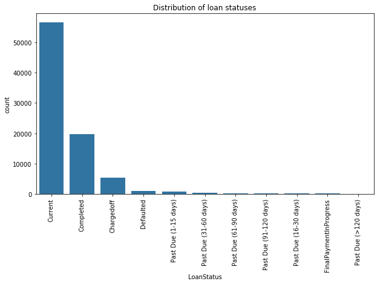

## The distibution of defaulted and completed against Emplyement status

The goal was to get statistics with respect to status of emplyment around dafalted and completed loans.

There are 19664 completed loans while those defalted is 6341

it was considental that most who defalted and completed their loans were the employed

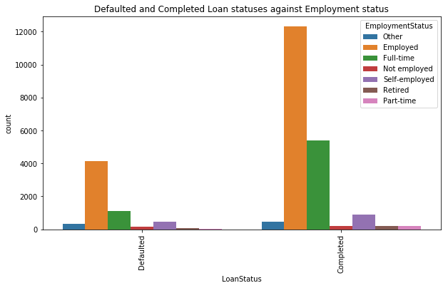

## The distribution of completed and defaulted loans agaiinst prosperity rating Alpha

As it can be seen that its clear that the most rating of the dfaulted loans is D while the mosting ratingamong the Completed loasn is D as well

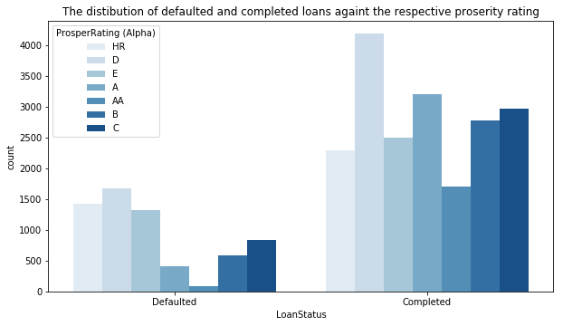

## The distribution of interest rates for defaulted and completed loans

It is also clear that those who defaulted on their loans had high intreret rates on their loans while those who complated has low rates on their loans

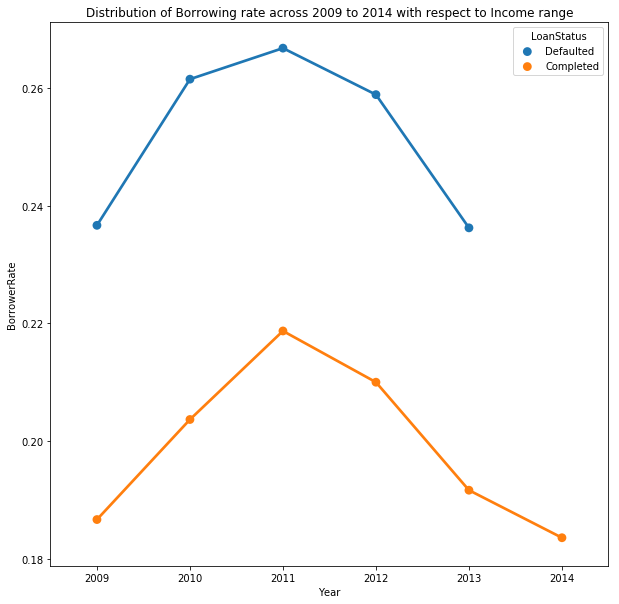